# Machine Learning Course Project: Classifying correctness of doing exercises using monitor data

Victoria Carreon

September 16, 2017

# Executive Summary

The goal of this assignment is to create a machine learning algorithm to predict the quality of barbell bicep curls using data from accelerometers on the belt, forearm, arm, and dumbbells. There are 5 Classifications: exactly according to the specification (Class A), throwing the elbows to the front (Class B), lifting the dumbbell only halfway (Class C), lowering the dumbbell only halfway (Class D) and throwing the hips to the front (Class E).

Training and testing data is provided. More information is available from the website here: http://groupware.les.inf.puc-rio.br/har (see the section on the Weight Lifting Exercise Dataset).

Three machine learning models were tested for this analysis: decision trees using rpart, random forests, and boosting using gbm. For each model, the data is trained on a subset of the original training set, and then tested on a subset of the original training set. Crossvalidation is used for both the random forests and boosting models. The model with the smallest out of sample error rate is random forests. This algorithm is used to predict the classification of the quality of barbell bicep curls on the original testing data set.

# Step 1: Load Packages needed for this project.

```r
library(caret)
```

```r
library(rpart)
library(rpart.plot)
library(RColorBrewer)
library(rattle)
library(randomForest)
library(knitr)
library(rattle)
```

# Step 2: Load and Clean Data

## A. Load Data

```r
if(!file.exists("data")){
  dir.create("data")
}
fileURL<-"https://d396qusza40orc.cloudfront.net/predmachlearn/pml-training.csv"
download.file(fileURL,destfile="./data/training.csv")
training <- read.csv(url(fileURL), na.strings=c("NA","#DIV/0!",""))
fileURL2<-"https://d396qusza40orc.cloudfront.net/predmachlearn/pml-testing.csv"
download.file(fileURL2,destfile="./data/testing.csv")
testing <- read.csv(url(fileURL2), na.strings=c("NA","#DIV/0!",""))
dim(training)
```

```
## [1] 19622   160
```

```r
dim(testing)
```

```
## [1]  20 160
```

There are 19622 observations and 160 variables in the training set. The testing set has 20 observations and 160 variables.

## B. Clean Training Set

First find all columns with names for the relevant variables. There are many variables with NAs or zeroes that can be excluded.

```r
trainingaccel<-grepl("^accel",names(training))
trainingtotal<-grepl("^total",names(training))
roll<-grepl("^roll",names(training))
pitch<-grepl("^pitch",names(training))
yaw<-grepl("^yaw",names(training))
magnet<-grepl("^magnet",names(training))
gyro<-grepl("^gyro",names(training))
```

Create dataframes with subsets of the data for the relevant variables.

```r
acceldata<-training[ ,trainingaccel]
totaldata<-training[,trainingtotal]
rolldata<-training[ ,roll]
pitchdata<-training[ ,pitch]
yawdata<-training[,yaw]
magnetdata<-training[,magnet]
gyrodata<-training[,gyro]
```

Combine all these data frames together and include column 160, which is the “classe” we will use as a predictor.

```r
trainClasse<-cbind(acceldata,rolldata,pitchdata,yawdata,magnetdata,gyrodata,totaldata,training[ ,160])
```

Add “Classe” as a name to last column.

```r
colnames(trainClasse)[53]<-'Classe'
str(trainClasse)
```

```
## 'data.frame':    19622 obs. of  53 variables:
##  $ accel_belt_x        : int  -21 -22 -20 -22 -21 -21 -22 -22 -20 -21 ...
##  $ accel_belt_y        : int  4 4 5 3 2 4 3 4 2 4 ...
##  $ accel_belt_z        : int  22 22 23 21 24 21 21 21 24 22 ...
##  $ accel_arm_x         : int  -288 -290 -289 -289 -289 -289 -289 -289 -288 -288 ...
##  $ accel_arm_y         : int  109 110 110 111 111 111 111 111 109 110 ...
##  $ accel_arm_z         : int  -123 -125 -126 -123 -123 -122 -125 -124 -122 -124 ...
##  $ accel_dumbbell_x    : int  -234 -233 -232 -232 -233 -234 -232 -234 -232 -235 ...
##  $ accel_dumbbell_y    : int  47 47 46 48 48 48 47 46 47 48 ...
##  $ accel_dumbbell_z    : int  -271 -269 -270 -269 -270 -269 -270 -272 -269 -270 ...
##  $ accel_forearm_x     : int  192 192 196 189 189 193 195 193 193 190 ...
##  $ accel_forearm_y     : int  203 203 204 206 206 203 205 205 204 205 ...
##  $ accel_forearm_z     : int  -215 -216 -213 -214 -214 -215 -215 -213 -214 -215 ...
##  $ roll_belt           : num  1.41 1.41 1.42 1.48 1.48 1.45 1.42 1.42 1.43 1.45 ...
##  $ roll_arm            : num  -128 -128 -128 -128 -128 -128 -128 -128 -128 -128 ...
```

[output cut: 39 more lines]

```r
dim(trainClasse)
```

```
## [1] 19622    53
```

Now we have 19,622 observations and 53 variables.

## C. Clean Testing Set

First find all columns with names for the relevant variables. This uses the same methodology as was used for the training set.

```r
testingaccel<-grepl("^accel",names(testing))
testingtotal<-grepl("^total",names(testing))
troll<-grepl("^roll",names(testing))
tpitch<-grepl("^pitch",names(testing))
tyaw<-grepl("^yaw",names(testing))
tmagnet<-grepl("^magnet",names(testing))
tgyro<-grepl("^gyro",names(testing))
```

Create dataframes with subsets of the data for the relevant variables.

```r
tacceldata<-testing[ ,testingaccel]
ttotaldata<-testing[,testingtotal]
trolldata<-testing[ ,troll]
tpitchdata<-testing[,tpitch]
tyawdata<-testing[,tyaw]
tmagnetdata<-testing[,tmagnet]
tgyrodata<-testing[,tgyro]
```

Combine all these data frames together and include column 160, which is the “problem ID” we will use as a predictor.

```r
testClasse<-cbind(tacceldata,trolldata,tpitchdata,tyawdata,tmagnetdata,tgyrodata,ttotaldata,testing[ ,160])
```

Add “Problem ID” as a name to last column.

```r
colnames(testClasse)[53]<-'problem.id'
dim(testClasse)
```

```
## [1] 20 53
```

Now we have 20 observations and 53 variables.

# Step 3: Set up new training and test sets to build a model.

The original training set needs to be subsetted into a training and testing set to buid a model. The original testing set will be used later as a validation set to see if the chosen model correctly predicts the classification.

```r
set.seed(400)
inTrain <- createDataPartition(training$classe, p=0.6, list=FALSE)
myTraining <- trainClasse[inTrain, ]
myTesting <- trainClasse[-inTrain, ]
dim(myTraining); dim(myTesting)
```

```
## [1] 11776    53
```

```
## [1] 7846   53
```

# Step 4: Try different machine learning models

## A. Model 1: Decision trees using “rpart”

Create the model and print a decision tree.

```r
set.seed(400)
modFit<-train(Classe~.,method="rpart",data=myTraining)
print(modFit$finalModel)
```

```
## n= 11776
##
## node), split, n, loss, yval, (yprob)
##       * denotes terminal node
##
##   1) root 11776 8428 A (0.28 0.19 0.17 0.16 0.18)
##     2) roll_belt< 130.5 10776 7437 A (0.31 0.21 0.19 0.18 0.11)
##       4) pitch_forearm< -33.95 944    5 A (0.99 0.0053 0 0 0) *
##       5) pitch_forearm>=-33.95 9832 7432 A (0.24 0.23 0.21 0.2 0.12)
##        10) yaw_belt>=169.5 507   55 A (0.89 0.049 0 0.053 0.0059) *
##        11) yaw_belt< 169.5 9325 7076 B (0.21 0.24 0.22 0.2 0.13)
##          22) magnet_dumbbell_z< -88.5 1218  519 A (0.57 0.28 0.047 0.072 0.026) *
##          23) magnet_dumbbell_z>=-88.5 8107 6110 C (0.15 0.24 0.25 0.22 0.14)
##            46) pitch_belt< -42.95 496   83 B (0.014 0.83 0.1 0.022 0.028) *
##            47) pitch_belt>=-42.95 7611 5665 C (0.16 0.2 0.26 0.24 0.15)
##              94) magnet_dumbbell_x>=-446.5 3261 2281 B (0.17 0.3 0.094 0.24 0.2)
##               188) roll_belt< 117.5 2049 1175 B (0.17 0.43 0.024 0.13 0.25) *
##               189) roll_belt>=117.5 1212  699 D (0.17 0.087 0.21 0.42 0.11) *
##              95) magnet_dumbbell_x< -446.5 4350 2710 C (0.16 0.12 0.38 0.23 0.11) *
##     3) roll_belt>=130.5 1000    9 E (0.009 0 0 0 0.99) *
```

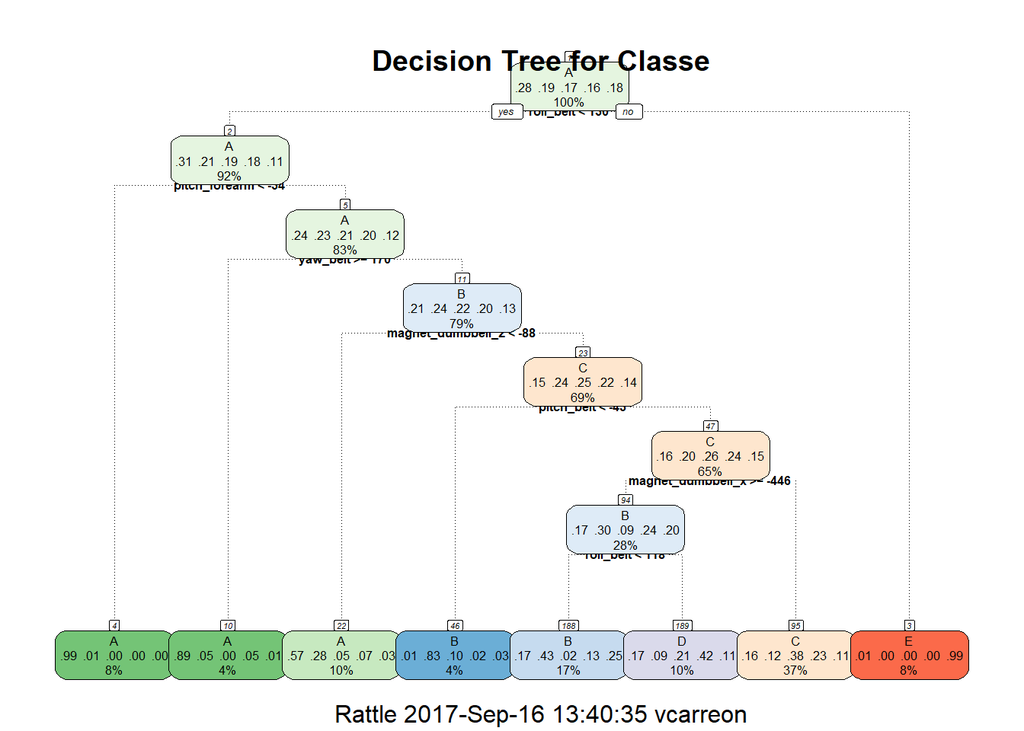

```r
fancyRpartPlot(modFit$finalModel,cex=.5, under.cex=1,shadow.offset=0,main="Decision Tree for Classe")
```

Predict with the rpart model.

```r
classepredict=predict(modFit,myTesting)
confusionMatrix(myTesting$Classe,classepredict)
```

```
## Confusion Matrix and Statistics
##
##           Reference
## Prediction    A    B    C    D    E
##          A 1349  233  479  166    5
##          B  247  864  337   70    0
##          C   41   55 1078  194    0
##          D   72  183  679  352    0
##          E   19  355  360   68  640
##
## Overall Statistics
##
##                Accuracy : 0.5459
##                  95% CI : (0.5348, 0.5569)
##     No Information Rate : 0.3738
##     P-Value [Acc > NIR] : < 2.2e-16
##
##                   Kappa : 0.4307
##  Mcnemar's Test P-Value : < 2.2e-16
##
## Statistics by Class:
##
##                      Class: A Class: B Class: C Class: D Class: E
## Sensitivity            0.7807   0.5112   0.3675  0.41412  0.99225
## Specificity            0.8557   0.8938   0.9410  0.86650  0.88863
## Pos Pred Value         0.6044   0.5692   0.7880  0.27372  0.44383
## Neg Pred Value         0.9325   0.8695   0.7136  0.92409  0.99922
## Prevalence             0.2202   0.2154   0.3738  0.10834  0.08221
## Detection Rate         0.1719   0.1101   0.1374  0.04486  0.08157
## Detection Prevalence   0.2845   0.1935   0.1744  0.16391  0.18379
## Balanced Accuracy      0.8182   0.7025   0.6543  0.64031  0.94044
```

## B. Model 2: Random Forest with cross validation with 4 folds.

```r
set.seed(400)
modFit2<-train(Classe~.,method="rf",trControl=trainControl(method="cv",number=4),data=myTraining)
print(modFit2$finalModel)
```

```
##
## Call:
##  randomForest(x = x, y = y, mtry = param$mtry)
##                Type of random forest: classification
##                      Number of trees: 500
## No. of variables tried at each split: 27
##
##         OOB estimate of  error rate: 0.88%
## Confusion matrix:
##      A    B    C    D    E class.error
## A 3342    3    3    0    0 0.001792115
## B   19 2254    5    1    0 0.010969724
## C    0   14 2032    8    0 0.010710808
## D    0    2   29 1895    4 0.018134715
## E    0    4    3    9 2149 0.007390300
```

```r
print(modFit2)
```

```
## Random Forest
##
## 11776 samples
##    52 predictor
##     5 classes: 'A', 'B', 'C', 'D', 'E'
##
## No pre-processing
## Resampling: Cross-Validated (4 fold)
## Summary of sample sizes: 8832, 8830, 8833, 8833
## Resampling results across tuning parameters:
##
##   mtry  Accuracy   Kappa
##    2    0.9866682  0.9831345
##   27    0.9881968  0.9850692
##   52    0.9838663  0.9795903
##
## Accuracy was used to select the optimal model using  the largest value.
## The final value used for the model was mtry = 27.
```

Which variables are important predictors? The variables roll_belt, pitch_forearm, yaw_belt, pitch_belt, and magnet_dumbbell_y are the five most important predictors.

```r
varImp(modFit2)
```

```
## rf variable importance
##
##   only 20 most important variables shown (out of 52)
##
##                      Overall
## roll_belt             100.00
## pitch_forearm          59.57
## yaw_belt               57.88
## pitch_belt             45.54
## magnet_dumbbell_y      44.05
## magnet_dumbbell_z      43.52
## roll_forearm           41.08
## accel_dumbbell_y       20.33
## accel_forearm_x        18.24
## roll_dumbbell          17.39
## magnet_belt_z          16.50
## magnet_dumbbell_x      16.39
## total_accel_dumbbell   14.04
## accel_belt_z           14.00
## magnet_forearm_z       13.34
## magnet_belt_y          13.00
## accel_dumbbell_z       12.51
## yaw_arm                11.88
## magnet_belt_x          11.12
## gyros_belt_z           10.93
```

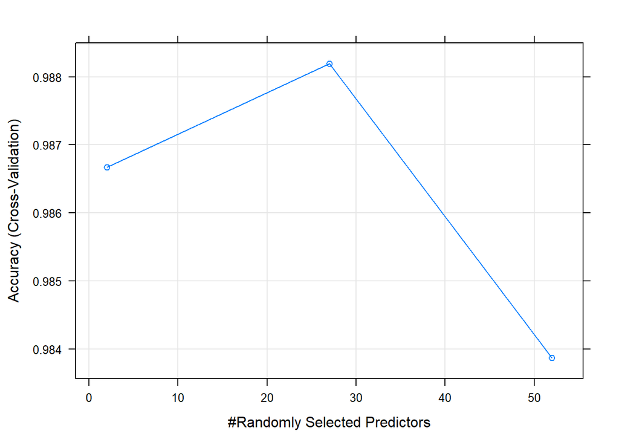

```r
plot(modFit2)
```

Predict with the Random Forest model.

```r
classepredict2=predict(modFit2,myTesting)
confusionMatrix(myTesting$Classe,classepredict2)
```

```
## Confusion Matrix and Statistics
##
##           Reference
## Prediction    A    B    C    D    E
##          A 2231    0    0    0    1
##          B    8 1502    8    0    0
##          C    0   18 1346    4    0
##          D    0    1   17 1268    0
##          E    0    0    5    1 1436
##
## Overall Statistics
##
##                Accuracy : 0.992
##                  95% CI : (0.9897, 0.9938)
##     No Information Rate : 0.2854
##     P-Value [Acc > NIR] : < 2.2e-16
##
##                   Kappa : 0.9898
##  Mcnemar's Test P-Value : NA
##
## Statistics by Class:
##
##                      Class: A Class: B Class: C Class: D Class: E
## Sensitivity            0.9964   0.9875   0.9782   0.9961   0.9993
## Specificity            0.9998   0.9975   0.9966   0.9973   0.9991
## Pos Pred Value         0.9996   0.9895   0.9839   0.9860   0.9958
## Neg Pred Value         0.9986   0.9970   0.9954   0.9992   0.9998
## Prevalence             0.2854   0.1939   0.1754   0.1622   0.1832
## Detection Rate         0.2843   0.1914   0.1716   0.1616   0.1830
## Detection Prevalence   0.2845   0.1935   0.1744   0.1639   0.1838
## Balanced Accuracy      0.9981   0.9925   0.9874   0.9967   0.9992
```

How does the accuracy look for the test set? Accuracy is .992, which is far better than the decision tree model using rpart. If accuracy is so high, could we be overfitting? Out of sample error is only .008.

## C. Model 3: Boosting with gbm method with five-fold cross validation.

```r
set.seed(400)
modFit3<-train(Classe~.,method="gbm",trControl=trainControl(method="repeatedcv",number=5,repeats=1),data=myTraining,verbose=F)
print(modFit3)
```

```
## Stochastic Gradient Boosting
##
## 11776 samples
##    52 predictor
##     5 classes: 'A', 'B', 'C', 'D', 'E'
##
## No pre-processing
## Resampling: Cross-Validated (5 fold, repeated 1 times)
## Summary of sample sizes: 9420, 9421, 9421, 9421, 9421
## Resampling results across tuning parameters:
##
##   interaction.depth  n.trees  Accuracy   Kappa
##   1                   50      0.7507649  0.6839200
##   1                  100      0.8204825  0.7728613
##   1                  150      0.8524970  0.8134001
##   2                   50      0.8553845  0.8168384
##   2                  100      0.9103267  0.8865301
##   2                  150      0.9324903  0.9145749
##   3                   50      0.8974189  0.8701568
##   3                  100      0.9427648  0.9275776
##   3                  150      0.9603438  0.9498267
##
## Tuning parameter 'shrinkage' was held constant at a value of 0.1
##
## Tuning parameter 'n.minobsinnode' was held constant at a value of 10
## Accuracy was used to select the optimal model using  the largest value.
## The final values used for the model were n.trees = 150,
##  interaction.depth = 3, shrinkage = 0.1 and n.minobsinnode = 10.
```

```r
varImp(modFit3)
```

```
## gbm variable importance
##
##   only 20 most important variables shown (out of 52)
##
##                   Overall
## roll_belt         100.000
## pitch_forearm      48.102
## yaw_belt           45.252
## magnet_dumbbell_z  31.339
## magnet_dumbbell_y  25.463
## roll_forearm       25.346
## magnet_belt_z      19.711
## pitch_belt         13.888
## accel_forearm_x    13.339
## gyros_belt_z       13.189
## accel_dumbbell_y   12.569
## accel_forearm_z    11.460
## roll_dumbbell      10.147
## gyros_dumbbell_y    9.195
## yaw_arm             7.762
## magnet_forearm_z    7.683
## accel_dumbbell_x    6.825
## magnet_forearm_x    5.932
## magnet_arm_z        5.544
## magnet_belt_x       4.852
```

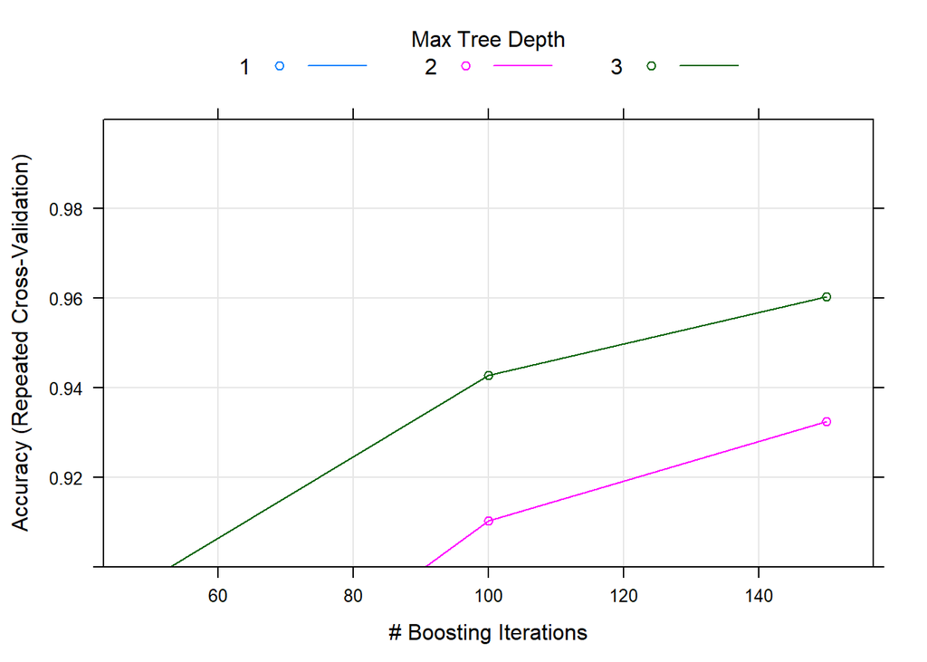

```r
plot(modFit3,ylim=c(.9,1))
```

The most important variables are: roll_belt, pitch_forearm, yaw_belt, magnet_dumbbell_z, and magnet_dumbbell_y. These are similar to the variables identified under the random forest model.

Predict with the Boosting model.

```r
classepredict3=predict(modFit3,myTesting)
confusionMatrix(myTesting$Classe,classepredict3)
```

```
## Confusion Matrix and Statistics
##
##           Reference
## Prediction    A    B    C    D    E
##          A 2191   21   13    5    2
##          B   40 1434   41    2    1
##          C    0   44 1298   23    3
##          D    1    4   48 1228    5
##          E    1   23   19   14 1385
##
## Overall Statistics
##
##                Accuracy : 0.9605
##                  95% CI : (0.9559, 0.9647)
##     No Information Rate : 0.2846
##     P-Value [Acc > NIR] : < 2.2e-16
##
##                   Kappa : 0.95
##  Mcnemar's Test P-Value : 1.309e-10
##
## Statistics by Class:
##
##                      Class: A Class: B Class: C Class: D Class: E
## Sensitivity            0.9812   0.9397   0.9147   0.9654   0.9921
## Specificity            0.9927   0.9867   0.9891   0.9912   0.9912
## Pos Pred Value         0.9816   0.9447   0.9488   0.9549   0.9605
## Neg Pred Value         0.9925   0.9855   0.9813   0.9933   0.9983
## Prevalence             0.2846   0.1945   0.1809   0.1621   0.1779
## Detection Rate         0.2793   0.1828   0.1654   0.1565   0.1765
## Detection Prevalence   0.2845   0.1935   0.1744   0.1639   0.1838
## Balanced Accuracy      0.9869   0.9632   0.9519   0.9783   0.9916
```

How does accuracy look for the test set? Accuracy is .9605 and the out of sample error rate is .0395. This is very good but it not as good as the Random Forest model.

# Step 5: Choose a model to predict against the original testing set.

The model with the highest accuracy is Random Forest, so this will be used to create predictions for the original testing data. This data has Problem ID instead of Classe, so the correct classification is not known.

```r
predictTest<-predict(modFit2,testing)
predictTest
```

```
##  [1] B A B A A E D B A A B C B A E E A B B B
## Levels: A B C D E
```

# Conclusion

Among the three algorithms tested (rpart, random forests, and gbm), random forests have the highest accuracy rate. This model is used to predict against the original testing data set. The high accuracy of the random forest model raises concerns that the data is being overfit to the training data and may not be as good of a predictor against a new set of data.

It is also important to note that the number of subjects in this dataset is small. There are only 4 individuals in the original dataset. The model chosen may reflect the Idiosyncrasies of these inidviduals and may not perform as well on a new set of subjects. This model could be refined by getting a larger sample size that reflects a diverse group of people.